# Q2

```python
import os
import random
from shutil import copyfile
from tensorflow.keras.preprocessing.image import ImageDataGenerator
import matplotlib.pyplot as plt
from tensorflow.keras.models import Sequential
from tensorflow.keras.layers import Conv2D, MaxPooling2D, Flatten, Dense, Dropout, BatchNormalization,DepthwiseConv2D
from tensorflow.keras.regularizers import l1_l2
from tensorflow.keras.applications import VGG16
# from tensorflow.keras.optimizers import Adam
from tensorflow.keras.callbacks import EarlyStopping
from tensorflow.keras.optimizers import legacy as keras_optimizer
import shutil
import matplotlib.pyplot as plt
import os
import shutil
import random
import matplotlib.pyplot as plt
```

```
2023-05-18 03:17:31.372933: I tensorflow/core/platform/cpu_feature_guard.cc:182] This TensorFlow binary is optimized to use available CPU instructions in performance-critical operations.
To enable the following instructions: AVX2 FMA, in other operations, rebuild TensorFlow with the appropriate compiler flags.
2023-05-18 03:17:33.379093: W tensorflow/compiler/tf2tensorrt/utils/py_utils.cc:38] TF-TRT Warning: Could not find TensorRT
```

```python
data_dir = 'split_data'
train_dir = os.path.join(data_dir, 'Train')
test_dir = os.path.join(data_dir, 'Test')
# Set the variables for the model
num_classes = 102
input_shape = (224, 224, 3)
batch_size = 32
epochs = 10
```

```python
# Set the paths for the dataset
train_dir = os.path.join(data_dir, 'Train')
test_dir = os.path.join(data_dir, 'Test')

# Create the data generator with image augmentation for training and validation
datagen = ImageDataGenerator(
    rescale=1./255,
    rotation_range=20,
    width_shift_range=0.2,
    height_shift_range=0.2,
    horizontal_flip=True,
    zoom_range=0.2,
    validation_split=0.2  # 80% of the data will be used for training, 20% for validation
)

# Load the training and validation data
train_generator = datagen.flow_from_directory(
    train_dir,
    target_size=input_shape[:2],
    batch_size=batch_size,
    class_mode='categorical',
    subset='training'  # Use the subset 'training' for the training data
)

validation_generator = datagen.flow_from_directory(
    train_dir,
    target_size=input_shape[:2],
    batch_size=batch_size,
    class_mode='categorical',
    subset='validation'  # Use the subset 'validation' for the validation data
)

# Load the test data
test_datagen = ImageDataGenerator(rescale=1./255)
test_generator = test_datagen.flow_from_directory(
    test_dir,
    target_size=input_shape[:2],
    batch_size=batch_size,
    class_mode='categorical',
    shuffle=False
)
```

```
Found 52976 images belonging to 102 classes.
Found 13193 images belonging to 102 classes.
Found 22783 images belonging to 102 classes.
```

```python
model = Sequential()

model.add(Conv2D(64, kernel_size=(3, 3), activation='relu', input_shape=input_shape))
model.add(Conv2D(64, kernel_size=(3, 3), activation='relu', kernel_regularizer=l1_l2(0.001)))
model.add(BatchNormalization())
model.add(MaxPooling2D(pool_size=(2, 2)))
model.add(Dropout(0.5))

model.add(Conv2D(128, kernel_size=(3, 3), activation='relu', kernel_regularizer=l1_l2(0.001)))
model.add(Conv2D(128, kernel_size=(3, 3), activation='relu', kernel_regularizer=l1_l2(0.001)))
model.add(BatchNormalization())
model.add(MaxPooling2D(pool_size=(2, 2)))
model.add(Dropout(0.5))

model.add(Conv2D(256, kernel_size=(3, 3), activation='relu', kernel_regularizer=l1_l2(0.001)))
model.add(Conv2D(256, kernel_size=(3, 3), activation='relu', kernel_regularizer=l1_l2(0.001)))
model.add(BatchNormalization())
model.add(MaxPooling2D(pool_size=(2, 2)))
model.add(Dropout(0.5))

model.add(Flatten())
model.add(Dense(512, activation='relu', kernel_regularizer=l1_l2(0.001)))
model.add(BatchNormalization())
model.add(Dropout(0.5))
model.add(Dense(num_classes, activation='softmax'))
```

[output not shown]

Convolutional Layers:

The model starts with a Conv2D layer with 64 filters, a kernel size of (3, 3), and a ReLU activation function. This layer performs convolutional operations on the input images to extract features. Another Conv2D layer with 64 filters and a kernel size of (3, 3) follows, also using ReLU activation. This layer includes a kernel regularizer (l1_l2) with a regularization strength of 0.001. Regularization helps prevent overfitting by adding a penalty term to the loss function. Batch normalization is applied after the convolutional layers. It normalizes the inputs to each layer, reducing the internal covariate shift and accelerating the training process. MaxPooling2D layer with a pool size of (2, 2) follows, which reduces the spatial dimensions of the data by taking the maximum value in each pooling window. This helps in downsampling and extracting the most salient features. Dropout with a rate of 0.5 is applied after each pooling layer. Dropout randomly sets a fraction of the input units to 0 during training, which helps prevent overfitting and improves the model's generalization. More Convolutional Layers:

Two sets of Conv2D layers with 128 filters and a kernel size of (3, 3) each are added. They are followed by ReLU activation and kernel regularization. Batch normalization and dropout are applied after each set of convolutional layers. Further Convolutional Layers:

Two more sets of Conv2D layers with 256 filters and a kernel size of (3, 3) each are added. They also use ReLU activation and kernel regularization. Batch normalization and dropout are applied after each set of convolutional layers. Flattening and Dense Layers:

The Flatten layer is used to convert the 2D feature maps from the previous convolutional layers into a 1D vector, which can be input to a fully connected neural network. Dense layer with 512 units and ReLU activation is added. It applies a linear transformation to the input data. Batch normalization and dropout are applied after the dense layer. Output Layer:

The final Dense layer with num_classes units is added with a softmax activation function. It produces the output probabilities for each class in the classification task. The choice of hyperparameters:

Kernel size: (3, 3) is a commonly used size for convolutional kernels. Activation functions: ReLU is chosen for all the convolutional and dense layers, except for the output layer where softmax is used to generate class probabilities. Regularization: l1_l2 regularization is used with a regularization strength of 0.001 to prevent overfitting. Batch normalization: Applied after convolutional layers and dense layers to normalize the inputs and improve training stability. Max pooling: Pooling with a size of (2, 2) reduces spatial dimensions and helps extract the most important features. Dropout: Applied after each pooling layer and after the dense layer to prevent overfitting by randomly dropping out units during training. Number of filters: The number of filters increases with the depth of the network, allowing the model to learn more complex features. Dense layers: The last dense layer has 512 units, which provides a higher-dimensional representation before the final classification layer.

```python
# Compile the model
# optimizer = keras_optimizer.Adam(learning_rate=0.01)
#######################

# from tensorflow.keras.optimizers import Adam
from tensorflow.keras.optimizers.legacy import Adam
optimizer = Adam(learning_rate=0.001)

#######################

# Define the EarlyStopping callback
early_stopping = EarlyStopping(monitor='val_loss', patience=3, verbose=1)

# Compile the model
optimizer = Adam(learning_rate=0.001)
model.compile(loss='categorical_crossentropy',
              optimizer=optimizer,
              metrics=['accuracy'])

# Train the model and track the training and validation loss
history = model.fit(
    train_generator,
    steps_per_epoch=train_generator.samples // batch_size,
    epochs=epochs,
    validation_data=validation_generator,
    validation_steps=validation_generator.samples // batch_size,
    callbacks=[early_stopping]  # Add the EarlyStopping callback
)
```

[output not shown]

```
2023-05-18 03:29:49.599099: I tensorflow/core/common_runtime/executor.cc:1197] [/device:CPU:0] (DEBUG INFO) Executor start aborting (this does not indicate an error and you can ignore this message): INVALID_ARGUMENT: You must feed a value for placeholder tensor 'Placeholder/_0' with dtype int32
	 [[{{node Placeholder/_0}}]]
```

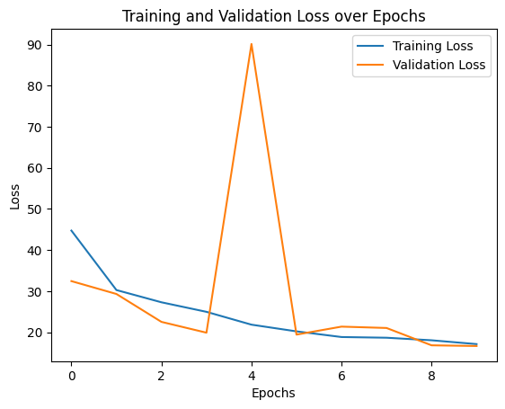

```
2023-05-18 05:34:51.207645: I tensorflow/core/common_runtime/executor.cc:1197] [/device:CPU:0] (DEBUG INFO) Executor start aborting (this does not indicate an error and you can ignore this message): INVALID_ARGUMENT: You must feed a value for placeholder tensor 'Placeholder/_0' with dtype int32
	 [[{{node Placeholder/_0}}]]
```

```
Test Loss: 16.40833282470703
Test Accuracy: 0.15015581250190735
```

```python
# Plot the training and validation loss over epochs
plt.plot(history.history['loss'], label='Training Loss')
plt.plot(history.history['val_loss'], label='Validation Loss')
plt.xlabel('Epochs')
plt.ylabel('Loss')
plt.title('Training and Validation Loss over Epochs')
plt.legend()
plt.show()

# Evaluate the model on the test set
test_loss, test_acc = model.evaluate(test_generator)
print('Test Loss:', test_loss)
print('Test Accuracy:', test_acc)
```

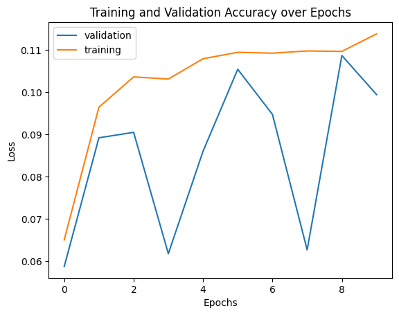

```
2023-05-18 05:37:37.405485: I tensorflow/core/common_runtime/executor.cc:1197] [/device:CPU:0] (DEBUG INFO) Executor start aborting (this does not indicate an error and you can ignore this message): INVALID_ARGUMENT: You must feed a value for placeholder tensor 'Placeholder/_0' with dtype int32
	 [[{{node Placeholder/_0}}]]
```

```
Test Loss: 16.40833282470703
Test Accuracy: 0.15015581250190735
```

```python
# Plot the training and validation loss over epochs
plt.plot(history.history['val_accuracy'], label='validation')
plt.plot(history.history['accuracy'], label='training')
plt.xlabel('Epochs')
plt.ylabel('Loss')
plt.title('Training and Validation Accuracy over Epochs')
plt.legend()
plt.show()

# Evaluate the model on the test set
test_loss, test_acc = model.evaluate(test_generator)
print('Test Loss:', test_loss)
print('Test Accuracy:', test_acc)
```

## Transfer Learning

```python
from tensorflow.keras.optimizers.legacy import Adam
optimizer = Adam(learning_rate=0.001)
early_stopping = EarlyStopping(monitor='val_loss', patience=3, verbose=1)
```

```
2023-05-18 05:38:37.529428: I tensorflow/core/common_runtime/executor.cc:1197] [/device:CPU:0] (DEBUG INFO) Executor start aborting (this does not indicate an error and you can ignore this message): INVALID_ARGUMENT: You must feed a value for placeholder tensor 'Placeholder/_0' with dtype int32
	 [[{{node Placeholder/_0}}]]
```

```
2023-05-18 05:46:51.157693: I tensorflow/core/common_runtime/executor.cc:1197] [/device:CPU:0] (DEBUG INFO) Executor start aborting (this does not indicate an error and you can ignore this message): INVALID_ARGUMENT: You must feed a value for placeholder tensor 'Placeholder/_0' with dtype int32
	 [[{{node Placeholder/_0}}]]
```

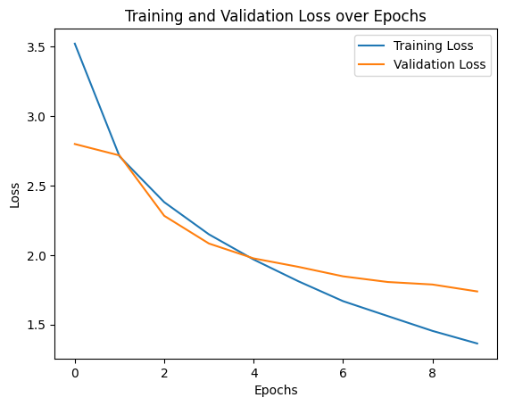

```
2023-05-18 07:21:06.056210: I tensorflow/core/common_runtime/executor.cc:1197] [/device:CPU:0] (DEBUG INFO) Executor start aborting (this does not indicate an error and you can ignore this message): INVALID_ARGUMENT: You must feed a value for placeholder tensor 'Placeholder/_0' with dtype int32
	 [[{{node Placeholder/_0}}]]
```

```
Test Loss: 1.2571213245391846
Test Accuracy: 0.6776982545852661
```

```python
# Load the pre-trained VGG16 model
base_model = VGG16(weights='imagenet', include_top=False, input_shape=input_shape)

# Freeze the pre-trained layers
for layer in base_model.layers[:-5]:
    layer.trainable = False

# Create a new model
model = Sequential()
model.add(base_model)

# Add additional layers for classification
model.add(Flatten())
model.add(Dense(512, activation='relu'))
model.add(BatchNormalization())
model.add(Dropout(0.5))
model.add(Dense(num_classes, activation='softmax'))

# Compile the model
model.compile(optimizer=Adam(learning_rate=0.0001), loss='categorical_crossentropy', metrics=['accuracy'])

# Train the model on the training data
history_vgg = model.fit(
    train_generator,
    steps_per_epoch=train_generator.samples // batch_size,
    epochs=epochs,
    validation_data=validation_generator,
    validation_steps=validation_generator.samples // batch_size,
    callbacks=[early_stopping]  # Add the EarlyStopping callback
)



# Plot the training and validation loss over epochs
plt.plot(history_vgg.history['loss'], label='Training Loss')
plt.plot(history_vgg.history['val_loss'], label='Validation Loss')
plt.xlabel('Epochs')
plt.ylabel('Loss')
plt.title('Training and Validation Loss over Epochs')
plt.legend()
plt.show()

# Evaluate the model on the test data
test_loss, test_acc = model.evaluate(test_generator)
print("Test Loss:", test_loss)
print("Test Accuracy:", test_acc)
```

Loading the pre-trained VGG16 model:

The VGG16 model is a popular CNN architecture that has been pre-trained on the ImageNet dataset, which contains millions of labeled images across 1,000 classes. By setting weights='imagenet', the model is initialized with pre-trained weights that have been learned from ImageNet. include_top=False ensures that the fully connected layers (top layers) of the VGG16 model are not included. We'll add our own classification layers later. Freezing the pre-trained layers:

The loop for layer in base_model.layers[:-5]: layer.trainable = False freezes the weights of the pre-trained layers, making them non-trainable. By freezing the layers, we retain the pre-trained knowledge and prevent them from being updated during the fine-tuning process. This is often done to avoid overfitting and leverage the powerful feature extraction capabilities of pre-trained models. Creating a new model:

A Sequential model is initialized to build the final classification layers. model.add(base_model) adds the pre-trained VGG16 model as the first layer in the new model. This allows us to leverage the features learned by VGG16 for our specific task. Flatten() is added to convert the 2D feature maps from the VGG16 model into a 1D vector. Dense(512, activation='relu') adds a fully connected layer with 512 units and ReLU activation. This layer learns high-level representations based on the extracted features. BatchNormalization() normalizes the inputs to the dense layer, enhancing training stability and accelerating convergence. Dropout(0.5) randomly sets 50% of the input units to 0 during training, which helps prevent overfitting and improves generalization. Dense(num_classes, activation='softmax') is the final dense layer with num_classes units and a softmax activation function, producing class probabilities for the classification task. The choice of hyperparameters in this code snippet is focused on fine-tuning the pre-trained VGG16 model:

Freezing layers: By freezing all layers except the last five, we allow the model to adapt the learned features to the specific task while retaining the earlier layers that capture general image features. Dense layer: The choice of 512 units in the dense layer is a common practice and can be adjusted based on the complexity of the task and available computational resources. Batch normalization: It is applied after the dense layer to normalize inputs and improve training stability. Dropout: A dropout rate of 0.5 is applied to mitigate overfitting. Softmax activation: The softmax activation in the last dense layer is used for multi-class classification, producing probabilities for each class.

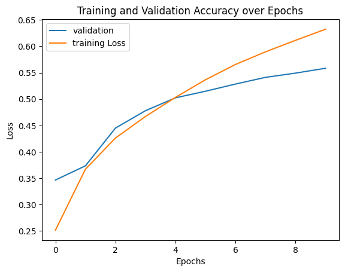

```
2023-05-18 07:22:19.371422: I tensorflow/core/common_runtime/executor.cc:1197] [/device:CPU:0] (DEBUG INFO) Executor start aborting (this does not indicate an error and you can ignore this message): INVALID_ARGUMENT: You must feed a value for placeholder tensor 'Placeholder/_0' with dtype int32
	 [[{{node Placeholder/_0}}]]
```

```
Test Loss: 1.2571213245391846
Test Accuracy: 0.6776982545852661
```

```python
# Plot the training and validation loss over epochs
plt.plot(history_vgg.history['val_accuracy'], label='validation')
plt.plot(history_vgg.history['accuracy'], label='training Loss')
plt.xlabel('Epochs')
plt.ylabel('Loss')
plt.title('Training and Validation Accuracy over Epochs')
plt.legend()
plt.show()

# Evaluate the model on the test set
test_loss, test_acc = model.evaluate(test_generator)
print('Test Loss:', test_loss)
print('Test Accuracy:', test_acc)
```

```python
from tensorflow.keras.applications import EfficientNetB4 as EN
from tensorflow.keras.models import Sequential
from tensorflow.keras.layers import Dense, GlobalAveragePooling2D, Dropout
from tensorflow.keras.optimizers.legacy import Adam

# Load the pre-trained EfficientNetB4 model
base_model = EN(weights='imagenet', include_top=False, input_shape=(224, 224, 3))

# Freeze the pre-trained layers
for layer in base_model.layers[:-5]:
    layer.trainable = False

# Create a new model
model = Sequential()
model.add(base_model)

# Add additional layers for classification
model.add(GlobalAveragePooling2D())
model.add(Dense(512, activation='relu'))
model.add(Dropout(0.5))
model.add(Dense(num_classes, activation='softmax'))

# Compile the model
model.compile(optimizer=Adam(learning_rate=0.0001), loss='categorical_crossentropy', metrics=['accuracy'])

# Train the model on your dataset
history_EN = model.fit(
    train_generator,
    steps_per_epoch=train_generator.samples // batch_size,
    epochs=epochs,
    validation_data=validation_generator,
    validation_steps=validation_generator.samples // batch_size,
    callbacks=[early_stopping]  # Add the EarlyStopping callback
)
# Evaluate the model on the test set
test_loss, test_acc = model.evaluate(test_generator)
print("Test Loss:", test_loss)
print("Test Accuracy:", test_acc)
```

```
2023-05-18 07:23:33.380685: I tensorflow/core/common_runtime/executor.cc:1197] [/device:CPU:0] (DEBUG INFO) Executor start aborting (this does not indicate an error and you can ignore this message): INVALID_ARGUMENT: You must feed a value for placeholder tensor 'Placeholder/_0' with dtype int32
	 [[{{node Placeholder/_0}}]]
2023-05-18 07:23:42.511126: E tensorflow/core/grappler/optimizers/meta_optimizer.cc:954] layout failed: INVALID_ARGUMENT: Size of values 0 does not match size of permutation 4 @ fanin shape insequential_2/efficientnetb4/block1b_drop/dropout/SelectV2-2-TransposeNHWCToNCHW-LayoutOptimizer
```

```
2023-05-18 07:32:07.212245: I tensorflow/core/common_runtime/executor.cc:1197] [/device:CPU:0] (DEBUG INFO) Executor start aborting (this does not indicate an error and you can ignore this message): INVALID_ARGUMENT: You must feed a value for placeholder tensor 'Placeholder/_0' with dtype int32
	 [[{{node Placeholder/_0}}]]
```

```
2023-05-18 09:07:53.799440: I tensorflow/core/common_runtime/executor.cc:1197] [/device:CPU:0] (DEBUG INFO) Executor start aborting (this does not indicate an error and you can ignore this message): INVALID_ARGUMENT: You must feed a value for placeholder tensor 'Placeholder/_0' with dtype int32
	 [[{{node Placeholder/_0}}]]
```

```
Test Loss: 3.722609043121338
Test Accuracy: 0.17951981723308563
```

Loading the pre-trained EfficientNetB4 model:

The EN (EfficientNet) model represents the EfficientNetB4 architecture, which is a scalable and efficient CNN model known for achieving state-of-the-art performance on various image classification tasks. By setting weights='imagenet', the model is initialized with pre-trained weights that have been learned from the ImageNet dataset. include_top=False ensures that the fully connected layers (top layers) of the EfficientNetB4 model are not included. We'll add our own classification layers later. Freezing the pre-trained layers:

The loop for layer in base_model.layers[:-5]: layer.trainable = False freezes the weights of the pre-trained layers, making them non-trainable. Freezing the layers helps retain the pre-trained knowledge and prevent them from being updated during the fine-tuning process. This is done to avoid overfitting and leverage the powerful feature extraction capabilities of pre-trained models. Creating a new model:

A Sequential model is initialized to build the final classification layers. model.add(base_model) adds the pre-trained EfficientNetB4 model as the first layer in the new model. This allows us to leverage the features learned by EfficientNetB4 for our specific task. GlobalAveragePooling2D() is added to perform global average pooling, which converts the spatial dimensions of the feature maps into a single vector. This reduces the computational complexity while preserving the most important features. Dense(512, activation='relu') adds a fully connected layer with 512 units and ReLU activation. This layer learns high-level representations based on the extracted features. Dropout(0.5) randomly sets 50% of the input units to 0 during training, which helps prevent overfitting and improves generalization. Dense(num_classes, activation='softmax') is the final dense layer with num_classes units and a softmax activation function, producing class probabilities for the classification task. Compiling the model:

The choice of hyperparameters in this code snippet is similar to the previous example, focusing on fine-tuning the pre-trained EfficientNetB4 model:

Freezing layers: By freezing all layers except the last five, we allow the model to adapt the learned features to the specific task while retaining the earlier layers that capture general image features. Dense layer: The choice of 512 units in the dense layer can be adjusted based on the complexity of the task and available computational resources.

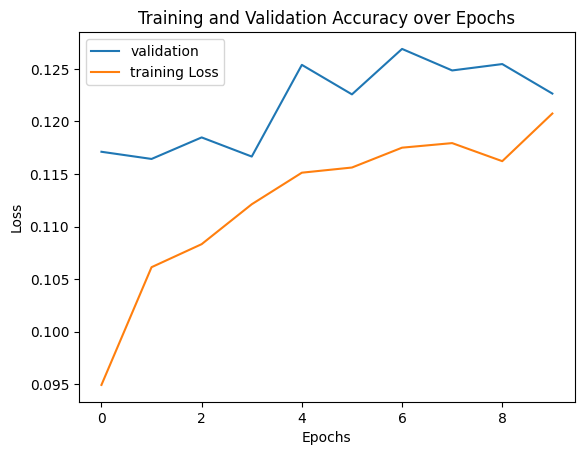

```
2023-05-18 09:09:32.097731: I tensorflow/core/common_runtime/executor.cc:1197] [/device:CPU:0] (DEBUG INFO) Executor start aborting (this does not indicate an error and you can ignore this message): INVALID_ARGUMENT: You must feed a value for placeholder tensor 'Placeholder/_0' with dtype int32
	 [[{{node Placeholder/_0}}]]
```

```
Test Loss: 3.722609043121338
Test Accuracy: 0.17951981723308563
```

```python
# Plot the training and validation loss over epochs
plt.plot(history_EN.history['val_accuracy'], label='validation')
plt.plot(history_EN.history['accuracy'], label='training Loss')
plt.xlabel('Epochs')
plt.ylabel('Loss')
plt.title('Training and Validation Accuracy over Epochs')
plt.legend()
plt.show()

# Evaluate the model on the test set
test_loss, test_acc = model.evaluate(test_generator)
print('Test Loss:', test_loss)
print('Test Accuracy:', test_acc)
```